# Ancient Greek semantic spaces: Analysis of evaluation results

Barbara McGillivray

# Initialization

## Load libraries and data, and set initial parameters

Load libraries:

```r
op <- options(warn = (-1)) # suppress warnings
library(readtext)
library(stringr)
options(op) # reset the default value
```

Directory and file names:

```r
path =  file.path("/Users", "bmcgillivray", "Documents", "OneDrive", "The Alan Turing Institute", "Martina Astrid Rodda - MAR dphil project", fsep = "/")
path_wl = paste(path, "TAL paper", "ancient lexicography", sep = "/")
word_list_file_name = 'word lists for philomen.txt'
```

# Initial parameters

Set parameters for initial exploration:

```r
window = 1
freq_threshold = 1
lexicon = "SCHMIDT"
```

## Word list

Read word list:

```r
word_list_file = readtext(file = paste(path_wl, word_list_file_name, sep = "/"), encoding = "UTF-8")
word_list_text = word_list_file$text
```

Process word list:

```r
word_list_text = gsub("^.+?asterisk\n", "", word_list_text)
word_list = strsplit(word_list_text, "\n")[[1]]
#word_list = strsplit(word_list, "\t")
#word_list = as.list(word_list, recursive = F)
word_list = data.frame(word_list)
word_list = word_list[!word_list$word_list == "",] # remove empty rows
word_list = gsub("*", "", word_list, fixed = T) # remove *
word_list = gsub("\t$", "", word_list, perl = T) # remove *
word_list = data.frame(word_list)
word_list = str_split(word_list$word_list, "\t", 3) # split by tab
word_list = data.frame(matrix(unlist(word_list), ncol = 3, byrow = T))
colnames(word_list) = c("ID", "lemma", "cat")
word_list2 = str_split(word_list$cat, "/", 2) # split by /
word_list2 = data.frame(matrix(unlist(word_list2), ncol = 2, byrow = T))
colnames(word_list2) = c("frequency_class", "polysemy_class")
word_list2$frequent = ifelse(word_list2$frequency_class == "F", T, F)
word_list2$polysemous = ifelse(word_list2$polysemy_class == "P", T, F)
word_list = data.frame(word_list[,c("lemma")], word_list2[,c("frequent", "polysemous")])
colnames(word_list)[1] = "lemma"
word_list
```

```
##        lemma frequent polysemous
## 1       ὄμμα     TRUE       TRUE
## 2      ἔργον     TRUE       TRUE
## 3      νόμος     TRUE       TRUE
## 4       γυνή     TRUE       TRUE
## 5     τραῦμα     TRUE       TRUE
## 6      μνήμη     TRUE       TRUE
## 7   θεραπεία     TRUE       TRUE
## 8       ἀνήρ     TRUE       TRUE
## 9     ἄνεμος     TRUE      FALSE
## 10     ἔλεος     TRUE      FALSE
## 11  ἐπιθυμία     TRUE      FALSE
## 12     ἐλπίς     TRUE      FALSE
## 13    ἡσυχία     TRUE      FALSE
## 14      εὐχή     TRUE      FALSE
```

[output cut: 18 more lines]

## Evaluation files

Function for creating name of evaluation file from parameters:

```r
path_ev_fun = function(path_var, window_var, freq_threshold_var, lexicon_var) {
  print(paste("Creating name of evaluation file for", path_var, window_var, freq_threshold_var, lexicon_var, sep = " "))
  path_ev = paste(path_var, "Evaluation", "output", paste("semantic-space-w", window_var, "_t", freq_threshold_var, sep = ""), paste("Lexicon_", lexicon_var, sep = ""), sep = "/")
  evaluation_file_name = paste("summary_overlap_Lexicon_", lexicon_var, "_semantic-space_w", window_var, "_t", freq_threshold_var, "_neighbours.txt", sep = "")
  print(paste("Path_ev:", path_ev, sep = " "))
  print(paste("Evaluation_file_name:", evaluation_file_name, sep = " "))
  outlist <- list("path_ev" = path_ev, "evaluation_file_name" = evaluation_file_name)
return(outlist)
}
```

Function for reading evaluation file:

```r
read_ev_file_fun = function(path_var, window_var, freq_threshold_var, lexicon_var){
  print(paste("Reading evaluation file for ", path_var, window_var, freq_threshold_var, lexicon_var, sep = " "))
  ev_list = path_ev_fun(path_var, window_var, freq_threshold_var, lexicon_var)
  path_ev = ev_list$path_ev
  evaluation_file_name = ev_list$evaluation_file_name
  evaluation_file = readtext(file = paste(path_ev, evaluation_file_name, sep = "/"), encoding = "UTF-8")
  evaluation_text = evaluation_file$text
  print(paste("Length of evaluation text:", length(evaluation_text[[1]])), sep = " ")
  return (evaluation_text)
}
```

Function for processing evaluation text:

```r
process_evaluation_text_fun = function(path_var, window_var, freq_threshold_var, lexicon_var){
  print(paste("Processing evaluation text for ", path_var, window_var, freq_threshold_var, lexicon_var, sep = " "))
  evaluation_text = read_ev_file_fun(path_var, window_var, freq_threshold_var, lexicon_var)
  evaluation_text = gsub("Mean of precision.+$", "", evaluation_text)
  evaluation = strsplit(evaluation_text, "\n")[[1]]
  evaluation = data.frame(evaluation)
  evaluation = str_split(evaluation$evaluation, "\t", 6) # split by tab
  cnames = evaluation[[1]]
  evaluation = data.frame(matrix(unlist(evaluation), ncol = 6, byrow = T))
  colnames(evaluation) = cnames
  evaluation = evaluation[2:nrow(evaluation),]
  evaluation$precision = as.numeric(as.character(evaluation$precision))
  evaluation$recall = as.numeric(as.character(evaluation$recall))
  print(paste("Dimension of evaluation data frame:", dim(evaluation), sep = " "))
  return (evaluation)
}
```

Create evaluation dataset:

```r
evaluation = process_evaluation_text_fun(path, window, freq_threshold, lexicon)
```

```
## [1] "Processing evaluation text for  /Users/bmcgillivray/Documents/OneDrive/The Alan Turing Institute/Martina Astrid Rodda - MAR dphil project 1 1 SCHMIDT"
## [1] "Reading evaluation file for  /Users/bmcgillivray/Documents/OneDrive/The Alan Turing Institute/Martina Astrid Rodda - MAR dphil project 1 1 SCHMIDT"
## [1] "Creating name of evaluation file for /Users/bmcgillivray/Documents/OneDrive/The Alan Turing Institute/Martina Astrid Rodda - MAR dphil project 1 1 SCHMIDT"
## [1] "Path_ev: /Users/bmcgillivray/Documents/OneDrive/The Alan Turing Institute/Martina Astrid Rodda - MAR dphil project/Evaluation/output/semantic-space-w1_t1/Lexicon_SCHMIDT"
## [1] "Evaluation_file_name: summary_overlap_Lexicon_SCHMIDT_semantic-space_w1_t1_neighbours.txt"
## [1] "Length of evaluation text: 1"
## [1] "Dimension of evaluation data frame: 1029"
## [2] "Dimension of evaluation data frame: 6"
```

## Combine datasets

Combine word list with evaluation dataset:

```r
data = merge(word_list, evaluation, by = c("lemma"))
```

## Distributions

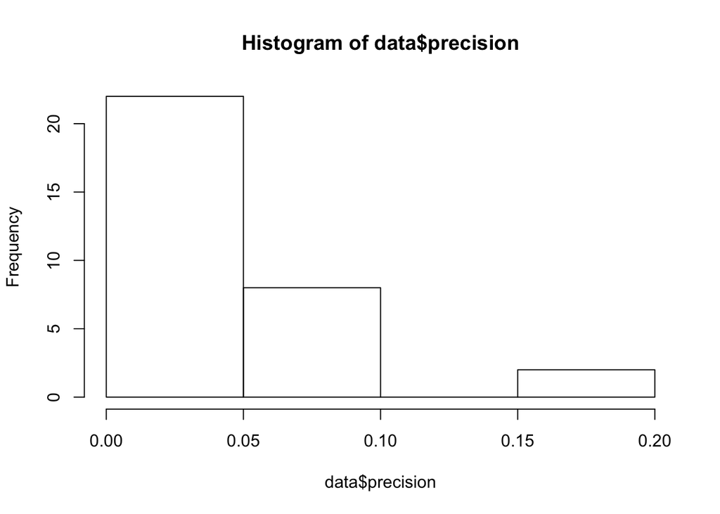

```r
hist(data$precision)
```

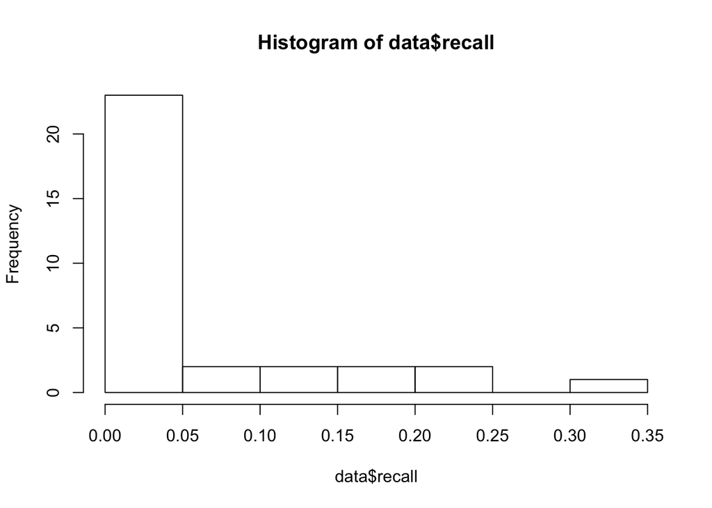

```r
hist(data$recall)
```

```r
shapiro.test(data$precision)
```

```
##
##  Shapiro-Wilk normality test
##
## data:  data$precision
## W = 0.63833, p-value = 1.172e-07
```

```r
shapiro.test(data$recall)
```

```
##
##  Shapiro-Wilk normality test
##
## data:  data$recall
## W = 0.62816, p-value = 8.599e-08
```

The distributions are not normal. However, the t-test assumes that the means of the different samples are normally distributed; it does not assume that the population is normally distributed. By the central limit theorem, means of samples from a population with finite variance approach a normal distribution regardless of the distribution of the population. Rules of thumb say that the sample means are basically normally distributed as long as the sample size is at least 20 or 30. For a t-test to be valid on a sample of smaller size, the population distribution would have to be approximately normal. The t-test is invalid for small samples from non-normal distributions, but it is valid for large samples from non-normal distributions. In our case we have 32 data points.

## Relationship between frequency and evaluation metrics

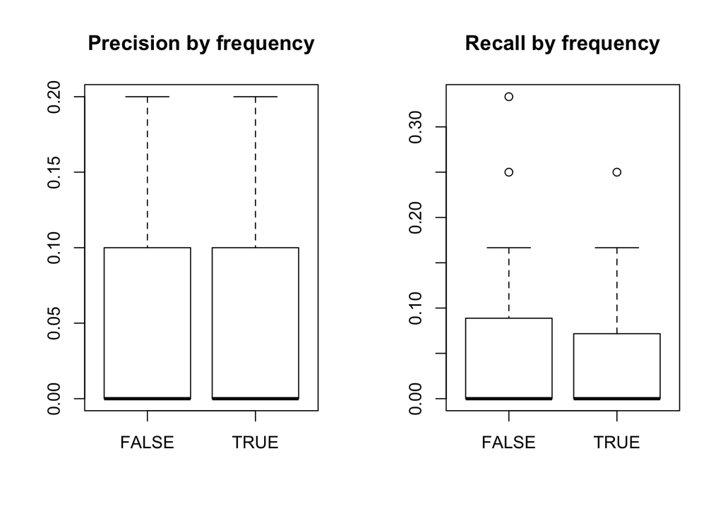

```r
par(mfrow = c(1,2))
boxplot(precision ~ frequent, data = data, main = "Precision by frequency")
boxplot(recall ~ frequent, data = data, main = "Recall by frequency")
```

```r
par(mfrow = c(1,1))
```

Frequency does not seem to make a difference to evaluation metrics.

Is there a difference between frequent and non-frequent lemmas in terms of their precision?

```r
tapply(data$precision, data$frequent, mean)
```

```
##  FALSE   TRUE
## 0.0375 0.0375
```

```r
tapply(data$precision, data$frequent, sd)
```

```
##      FALSE       TRUE
## 0.06191392 0.06191392
```

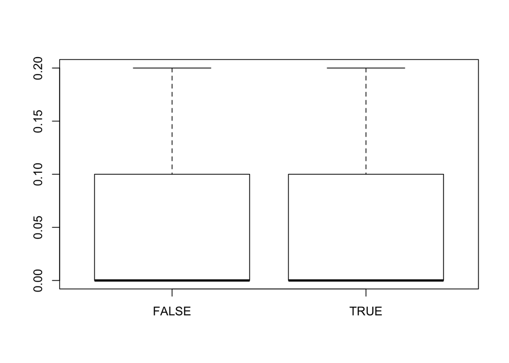

```r
boxplot(data$precision ~ data$frequent)
```

```r
t.test(precision ~ frequent, data = data, paired = F)
```

```
##
##  Welch Two Sample t-test
##
## data:  precision by frequent
## t = 0, df = 30, p-value = 1
## alternative hypothesis: true difference in means is not equal to 0
## 95 percent confidence interval:
##  -0.04470509  0.04470509
## sample estimates:
## mean in group FALSE  mean in group TRUE
##              0.0375              0.0375
```

No.

Is there a difference between frequent and non-frequent lemmas in terms of their recall?

```r
tapply(data$recall, data$frequent, mean)
```

```
##      FALSE       TRUE
## 0.05797697 0.04195350
```

```r
tapply(data$recall, data$frequent, sd)
```

```
##     FALSE      TRUE
## 0.1051991 0.0758737
```

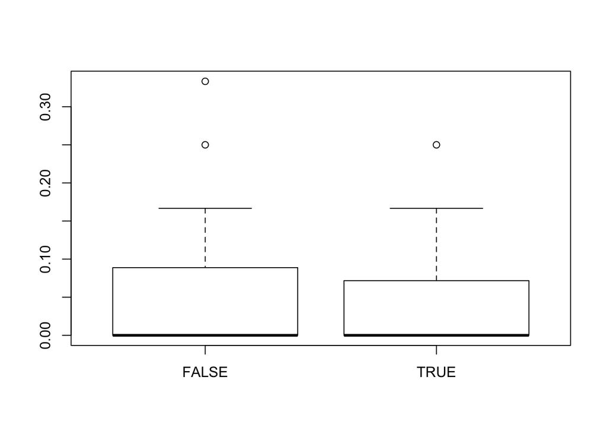

```r
boxplot(data$recall ~ data$frequent)
```

```r
t.test(recall ~ frequent, data = data, paired = F)
```

```
##
##  Welch Two Sample t-test
##
## data:  recall by frequent
## t = 0.49415, df = 27.282, p-value = 0.6252
## alternative hypothesis: true difference in means is not equal to 0
## 95 percent confidence interval:
##  -0.05047807  0.08252501
## sample estimates:
## mean in group FALSE  mean in group TRUE
##          0.05797697          0.04195350
```

No.

The high p-value indicates that we cannot reject the null hypothesis that the two groups have the same mean.

## Relationship between polysemy and evaluation metrics

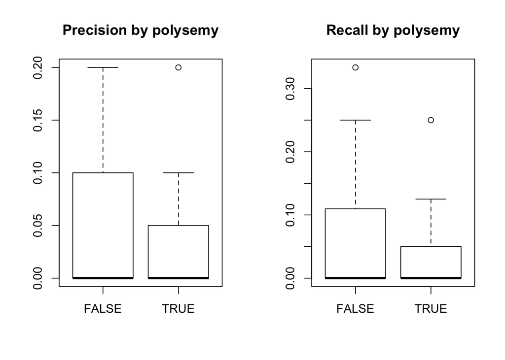

```r
par(mfrow = c(1,2))
boxplot(precision ~ polysemous, data = data, main = "Precision by polysemy")
boxplot(recall ~ polysemous, data = data, main = "Recall by polysemy")
```

```r
par(mfrow = c(1,1))
```

Polysemy, rather than frequency, seems to make a difference to evaluation metrics, with polysemous lemmas performing worse than monosemous ones.

Is there a difference between polysemous and monosemous lemmas in terms of their precision?

```r
tapply(data$precision, data$polysemous, mean)
```

```
##   FALSE    TRUE
## 0.04375 0.03125
```

```r
tapply(data$precision, data$polysemous, sd)
```

```
##      FALSE       TRUE
## 0.06291529 0.06020797
```

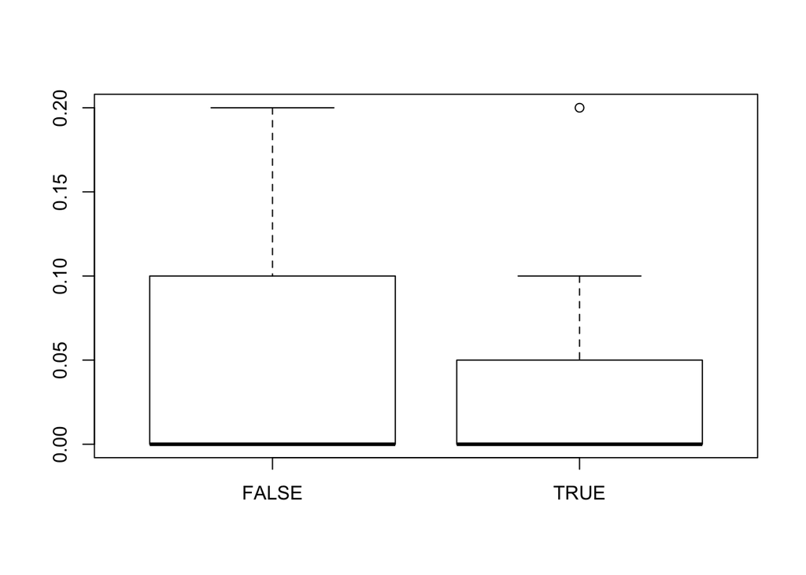

```r
boxplot(data$precision ~ data$polysemous)
```

```r
t.test(precision ~ polysemous, data = data, paired = F)
```

```
##
##  Welch Two Sample t-test
##
## data:  precision by polysemous
## t = 0.57417, df = 29.942, p-value = 0.5701
## alternative hypothesis: true difference in means is not equal to 0
## 95 percent confidence interval:
##  -0.03196507  0.05696507
## sample estimates:
## mean in group FALSE  mean in group TRUE
##             0.04375             0.03125
```

No. The high p-value indicates that we cannot reject the null hypothesis that the two groups have the same mean.

Is there a difference between polysemous and monosemous lemmas in terms of their recall?

```r
tapply(data$recall, data$polysemous, mean)
```

```
##      FALSE       TRUE
## 0.06329853 0.03663194
```

```r
tapply(data$recall, data$polysemous, sd)
```

```
##      FALSE       TRUE
## 0.10637037 0.07257194
```

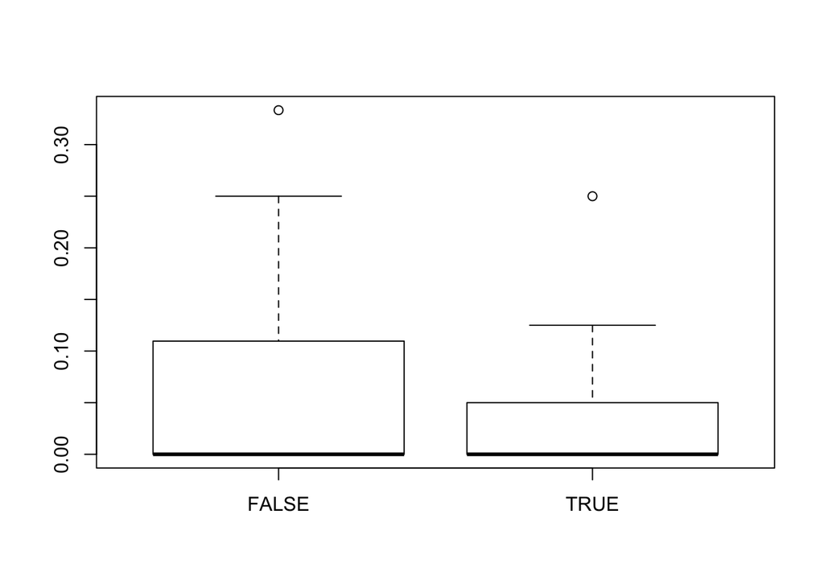

```r
boxplot(data$recall ~ data$polysemous)
```

```r
t.test(recall ~ polysemous, data = data, paired = F)
```

```
##
##  Welch Two Sample t-test
##
## data:  recall by polysemous
## t = 0.82836, df = 26.477, p-value = 0.4149
## alternative hypothesis: true difference in means is not equal to 0
## 95 percent confidence interval:
##  -0.03944728  0.09278045
## sample estimates:
## mean in group FALSE  mean in group TRUE
##          0.06329853          0.03663194
```

No. The high p-value indicates that we cannot reject the null hypothesis that the two groups have the same mean.

## Regression models

```r
ev.pr.lm <- lm(precision ~ frequent + polysemous, data = data)
summary(ev.pr.lm)
```

```
##
## Call:
## lm(formula = precision ~ frequent + polysemous, data = data)
##
## Residuals:
##      Min       1Q   Median       3Q      Max
## -0.04375 -0.04375 -0.03125  0.05625  0.16875
##
## Coefficients:
##                  Estimate Std. Error t value Pr(>|t|)
## (Intercept)     4.375e-02  1.918e-02   2.281    0.030 *
## frequentTRUE   -1.472e-18  2.214e-02   0.000    1.000
## polysemousTRUE -1.250e-02  2.214e-02  -0.565    0.577
## ---
## Signif. codes:  0 '***' 0.001 '**' 0.01 '*' 0.05 '.' 0.1 ' ' 1
##
## Residual standard error: 0.06263 on 29 degrees of freedom
## Multiple R-squared:  0.01087,    Adjusted R-squared:  -0.05735
## F-statistic: 0.1593 on 2 and 29 DF,  p-value: 0.8534
```

Model diagnostics:

```
## hat values (leverages) are all = 0.09375
##  and there are no factor predictors; no plot no. 5
```

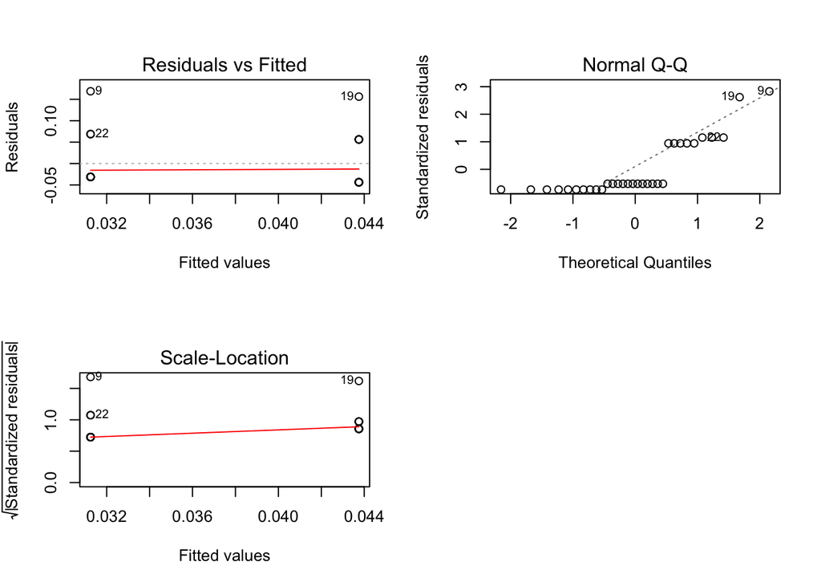

```r
par(mfrow = c(2,2))
plot(ev.pr.lm)
```

```r
par(mfrow = c(1,1))
```

Not a good model.

```r
ev.re.lm <- lm(recall ~ frequent + polysemous, data = data)
summary(ev.re.lm)
```

```
##
## Call:
## lm(formula = recall ~ frequent + polysemous, data = data)
##
## Residuals:
##       Min        1Q    Median        3Q       Max
## -0.071310 -0.055287 -0.044644  0.008989  0.262023
##
## Coefficients:
##                Estimate Std. Error t value Pr(>|t|)
## (Intercept)     0.07131    0.02824   2.525   0.0173 *
## frequentTRUE   -0.01602    0.03261  -0.491   0.6268
## polysemousTRUE -0.02667    0.03261  -0.818   0.4201
## ---
## Signif. codes:  0 '***' 0.001 '**' 0.01 '*' 0.05 '.' 0.1 ' ' 1
##
## Residual standard error: 0.09223 on 29 degrees of freedom
## Multiple R-squared:  0.03043,    Adjusted R-squared:  -0.03643
## F-statistic: 0.4552 on 2 and 29 DF,  p-value: 0.6388
```

Model diagnostics:

```
## hat values (leverages) are all = 0.09375
##  and there are no factor predictors; no plot no. 5
```

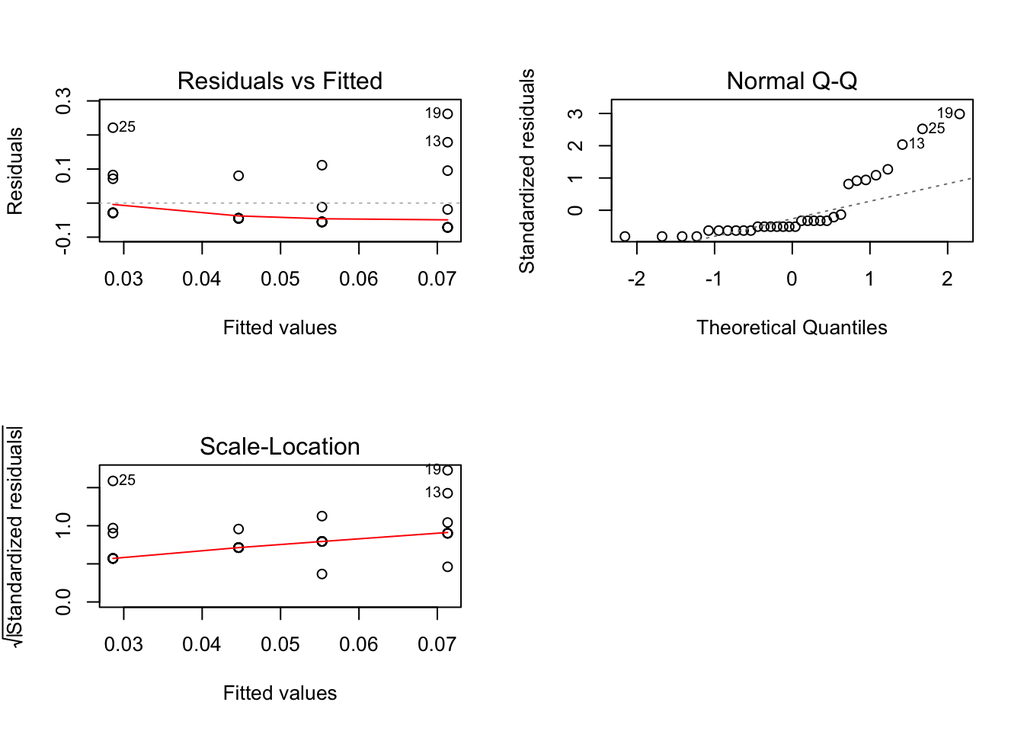

```r
par(mfrow = c(2,2))
plot(ev.re.lm)
```

```r
par(mfrow = c(1,1))
```

Not a good model.

# All parameter combinations

Loop over all parameter combinations:

```r
windows = c(1,5,10)
#windows = c(5,10)
freq_thresholds = c(1,20,50,100)
#freq_thresholds = c(20,50,100)
lexicons = c("SCHMIDT", "AGWN", "POLLUX")
#lexicons = c("POLLUX")
```

## Create datasets

```r
evaluations = data.frame(lemma=(character()),
                 precision=double(),
                 recall=double(),
                 window=integer(),
                 freq_threshold=integer(),
                 lexicon=factor(),
                 stringsAsFactors=FALSE)
for (window in windows) {
  print(paste("Window:", window, sep = ""))
  for (f in freq_thresholds) {
    print(paste("Freq threshold:", f, sep = ""))
    for (lexicon in lexicons){
      print(paste("Lexicon:", lexicon, sep = ""))
      if ( !(window == 1 && f ==    1 && lexicon == "AGWN") && !(window == 5 && f ==    1   && lexicon ==   "AGWN") && !(window == 10   && f ==1 && lexicon ==  "AGWN")){
        print(paste("Continue with", "window:", window, "Freq threshold:", f, "Lexicon:", lexicon, sep = " "))
      evaluation = process_evaluation_text_fun(path, window, f, lexicon)
      evaluation = evaluation[,c("lemma", "precision", "recall")]
      evaluation$window = window
      evaluation$freq_threshold = f
      evaluation$lexicon = lexicon
      evaluations = rbind(evaluations, evaluation)}
    }
  }
}
```

```
## [1] "Window:1"
## [1] "Freq threshold:1"
## [1] "Lexicon:SCHMIDT"
## [1] "Continue with window: 1 Freq threshold: 1 Lexicon: SCHMIDT"
## [1] "Processing evaluation text for  /Users/bmcgillivray/Documents/OneDrive/The Alan Turing Institute/Martina Astrid Rodda - MAR dphil project 1 1 SCHMIDT"
## [1] "Reading evaluation file for  /Users/bmcgillivray/Documents/OneDrive/The Alan Turing Institute/Martina Astrid Rodda - MAR dphil project 1 1 SCHMIDT"
## [1] "Creating name of evaluation file for /Users/bmcgillivray/Documents/OneDrive/The Alan Turing Institute/Martina Astrid Rodda - MAR dphil project 1 1 SCHMIDT"
## [1] "Path_ev: /Users/bmcgillivray/Documents/OneDrive/The Alan Turing Institute/Martina Astrid Rodda - MAR dphil project/Evaluation/output/semantic-space-w1_t1/Lexicon_SCHMIDT"
## [1] "Evaluation_file_name: summary_overlap_Lexicon_SCHMIDT_semantic-space_w1_t1_neighbours.txt"
## [1] "Length of evaluation text: 1"
## [1] "Dimension of evaluation data frame: 1029"
## [2] "Dimension of evaluation data frame: 6"
## [1] "Lexicon:AGWN"
## [1] "Lexicon:POLLUX"
## [1] "Continue with window: 1 Freq threshold: 1 Lexicon: POLLUX"
```

[output cut: 333 more lines]

```r
evaluations$lexicon = as.factor(evaluations$lexicon)
```

Prepare final dataset:

```r
data = merge(word_list, evaluations, by = c("lemma"))
data$lexicon = as.factor(data$lexicon)
dim(data)
```

```
## [1] 690   8
```

```r
summary(data)
```

```
##      lemma      frequent       polysemous        precision
##  ἔχθρα  : 33   Mode :logical   Mode :logical   Min.   :0.00000
##  ἡσυχία : 33   FALSE:330       FALSE:360       1st Qu.:0.00000
##  μῖσος  : 33   TRUE :360       TRUE :330       Median :0.00000
##  ἄδεια  : 21                                   Mean   :0.05565
##  ἄνεμος : 21                                   3rd Qu.:0.10000
##  ἀνήρ   : 21                                   Max.   :0.40000
##  (Other):528
##      recall            window       freq_threshold      lexicon
##  Min.   :0.00000   Min.   : 1.000   Min.   :  1.00   AGWN   :279
##  1st Qu.:0.00000   1st Qu.: 1.000   1st Qu.: 20.00   POLLUX : 36
##  Median :0.00000   Median : 5.000   Median : 50.00   SCHMIDT:375
##  Mean   :0.05318   Mean   : 5.333   Mean   : 47.07
##  3rd Qu.:0.08333   3rd Qu.:10.000   3rd Qu.:100.00
##  Max.   :0.50000   Max.   :10.000   Max.   :100.00
##
```

## Distributions

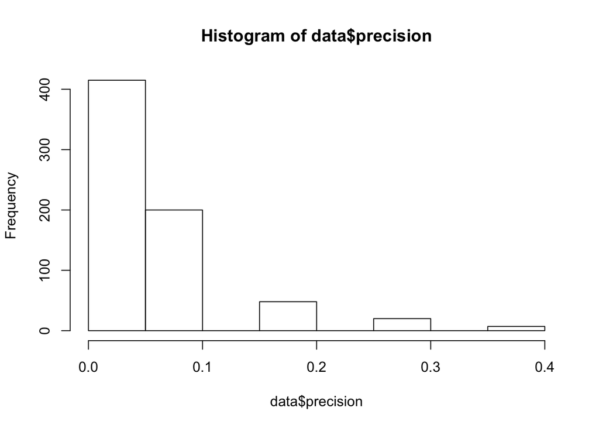

```r
hist(data$precision)
```

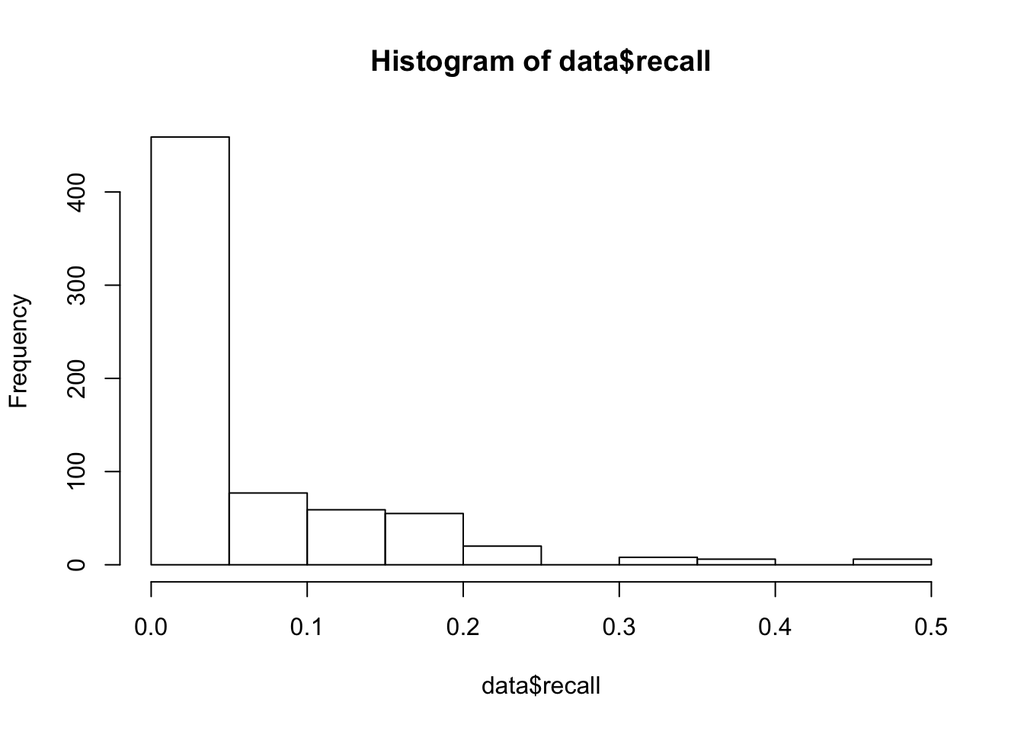

```r
hist(data$recall)
```

```r
shapiro.test(data$precision)
```

```
##
##  Shapiro-Wilk normality test
##
## data:  data$precision
## W = 0.68646, p-value < 2.2e-16
```

```r
shapiro.test(data$recall)
```

```
##
##  Shapiro-Wilk normality test
##
## data:  data$recall
## W = 0.6561, p-value < 2.2e-16
```

The distributions are not normal. However, The t-test assumes that the means of the different samples are normally distributed; it does not assume that the population is normally distributed. By the central limit theorem, means of samples from a population with finite variance approach a normal distribution regardless of the distribution of the population. Rules of thumb say that the sample means are basically normally distributed as long as the sample size is at least 20 or 30. For a t-test to be valid on a sample of smaller size, the population distribution would have to be approximately normal. The t-test is invalid for small samples from non-normal distributions, but it is valid for large samples from non-normal distributions. In our case we have 690 data points.

# Relationship between frequency and evaluation metrics

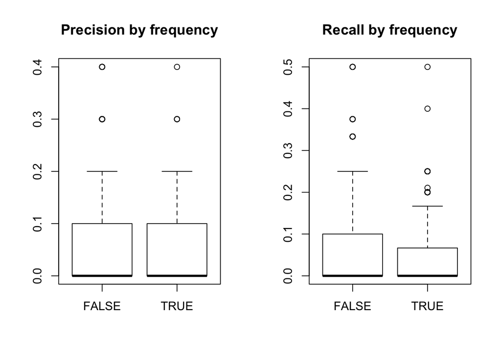

```r
par(mfrow = c(1,2))
boxplot(precision ~ frequent, data = data, main = "Precision by frequency")
boxplot(recall ~ frequent, data = data, main = "Recall by frequency")
```

```r
par(mfrow = c(1,1))
```

Frequency does not seem to make a difference to evaluation metrics.

Is there a statistically significant difference between frequent and non-frequent lemmas in terms of their precision?

```r
tapply(data$precision, data$frequent, mean)
```

```
##      FALSE       TRUE
## 0.06181818 0.05000000
```

```r
tapply(data$precision, data$frequent, sd)
```

```
##      FALSE       TRUE
## 0.09515479 0.06881407
```

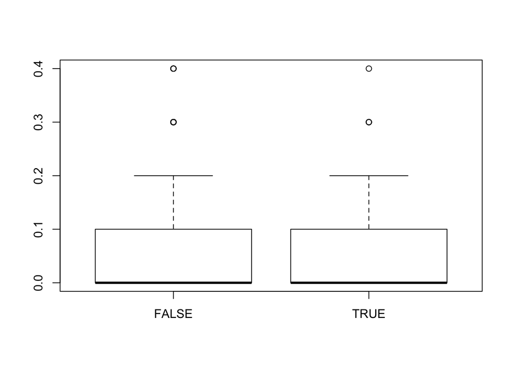

```r
boxplot(data$precision ~ data$frequent)
```

```r
t.test(precision ~ frequent, data = data, paired = F)
```

```
##
##  Welch Two Sample t-test
##
## data:  precision by frequent
## t = 1.855, df = 594.79, p-value = 0.0641
## alternative hypothesis: true difference in means is not equal to 0
## 95 percent confidence interval:
##  -0.0006944971  0.0243308607
## sample estimates:
## mean in group FALSE  mean in group TRUE
##          0.06181818          0.05000000
```

No.

Is there a statistically significant difference between frequent and non-frequent lemmas in terms of their recall?

```r
tapply(data$recall, data$frequent, mean)
```

```
##      FALSE       TRUE
## 0.05868311 0.04813696
```

```r
tapply(data$recall, data$frequent, sd)
```

```
##      FALSE       TRUE
## 0.10258151 0.07662795
```

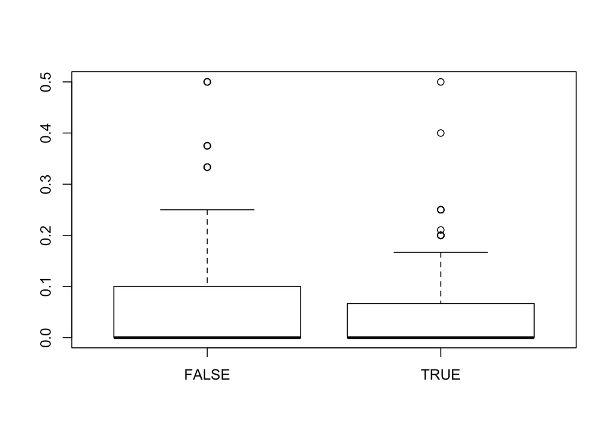

```r
boxplot(data$recall ~ data$frequent)
```

```r
t.test(recall ~ frequent, data = data, paired = F)
```

```
##
##  Welch Two Sample t-test
##
## data:  recall by frequent
## t = 1.5191, df = 606.28, p-value = 0.1293
## alternative hypothesis: true difference in means is not equal to 0
## 95 percent confidence interval:
##  -0.003088139  0.024180439
## sample estimates:
## mean in group FALSE  mean in group TRUE
##          0.05868311          0.04813696
```

No.

The high p-value indicates that we cannot reject the null hypothesis that the two groups have the same mean.

# Relationship between polysemy and evaluation metrics

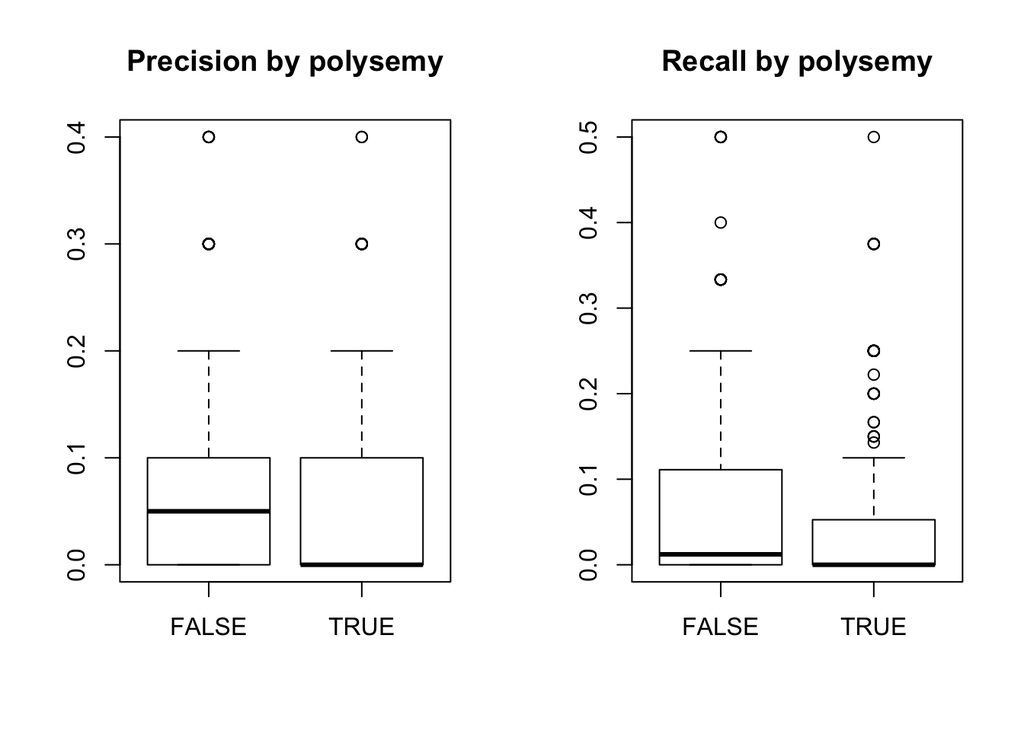

```r
par(mfrow = c(1,2))
boxplot(precision ~ polysemous, data = data, main = "Precision by polysemy")
boxplot(recall ~ polysemous, data = data, main = "Recall by polysemy")
```

```r
par(mfrow = c(1,1))
```

Polysemy, rather than frequency, seems to make a difference to evaluation metrics, with polysemous lemmas performing worse than monosemous ones.

Is there a statistically significant difference between polysemous and monosemous lemmas in terms of their precision?

```r
tapply(data$precision, data$polysemous, mean)
```

```
##      FALSE       TRUE
## 0.06916667 0.04090909
```

```r
tapply(data$precision, data$polysemous, sd)
```

```
##      FALSE       TRUE
## 0.08652612 0.07554719
```

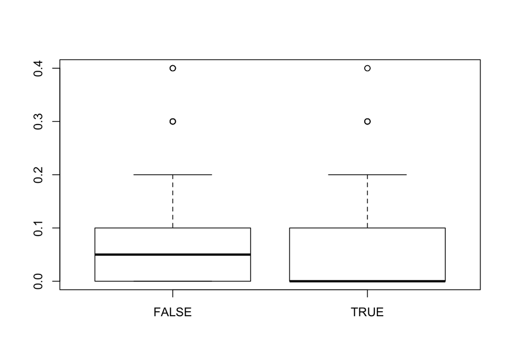

```r
boxplot(data$precision ~ data$polysemous)
```

```r
t.test(precision ~ polysemous, data = data, paired = F)
```

```
##
##  Welch Two Sample t-test
##
## data:  precision by polysemous
## t = 4.5785, df = 686.39, p-value = 5.561e-06
## alternative hypothesis: true difference in means is not equal to 0
## 95 percent confidence interval:
##  0.01613962 0.04037554
## sample estimates:
## mean in group FALSE  mean in group TRUE
##          0.06916667          0.04090909
```

Yes. The low p-value indicates that we can reject the null hypothesis that the two groups have the same mean.

Is there a statistically significant difference between polysemous and monosemous lemmas in terms of their recall?

```r
tapply(data$recall, data$polysemous, mean)
```

```
##      FALSE       TRUE
## 0.06662527 0.03851405
```

```r
tapply(data$recall, data$polysemous, sd)
```

```
##      FALSE       TRUE
## 0.09638540 0.08023477
```

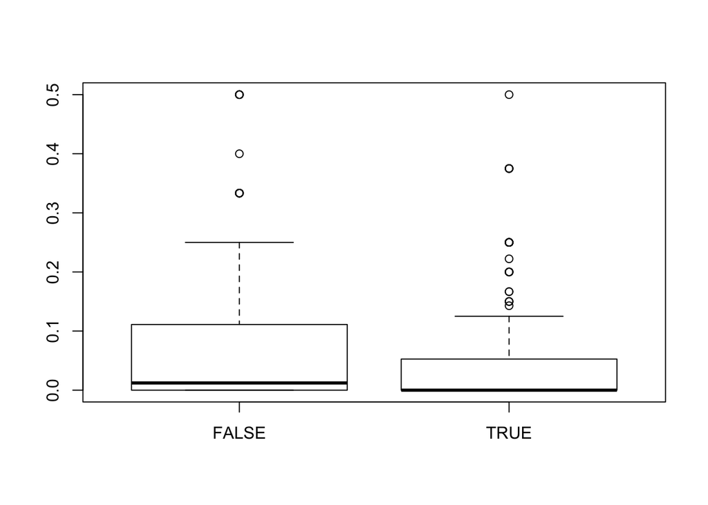

```r
boxplot(data$recall ~ data$polysemous)
```

```r
t.test(recall ~ polysemous, data = data, paired = F)
```

```
##
##  Welch Two Sample t-test
##
## data:  recall by polysemous
## t = 4.176, df = 681.79, p-value = 3.351e-05
## alternative hypothesis: true difference in means is not equal to 0
## 95 percent confidence interval:
##  0.01489414 0.04132829
## sample estimates:
## mean in group FALSE  mean in group TRUE
##          0.06662527          0.03851405
```

Yes. The low p-value indicates that we can reject the null hypothesis that the two groups have the same mean.

## Regression models

```r
ev.pr.lm <- lm(precision ~ frequent + polysemous, data = data)
summary(ev.pr.lm)
```

```
##
## Call:
## lm(formula = precision ~ frequent + polysemous, data = data)
##
## Residuals:
##      Min       1Q   Median       3Q      Max
## -0.07584 -0.06333 -0.03477  0.03667  0.35272
##
## Coefficients:
##                 Estimate Std. Error t value Pr(>|t|)
## (Intercept)     0.075839   0.005410  14.017  < 2e-16 ***
## frequentTRUE   -0.012511   0.006196  -2.019   0.0439 *
## polysemousTRUE -0.028561   0.006196  -4.609 4.81e-06 ***
## ---
## Signif. codes:  0 '***' 0.001 '**' 0.01 '*' 0.05 '.' 0.1 ' ' 1
##
## Residual standard error: 0.08128 on 687 degrees of freedom
## Multiple R-squared:  0.03496,    Adjusted R-squared:  0.03215
## F-statistic: 12.44 on 2 and 687 DF,  p-value: 4.914e-06
```

Model diagnostics:

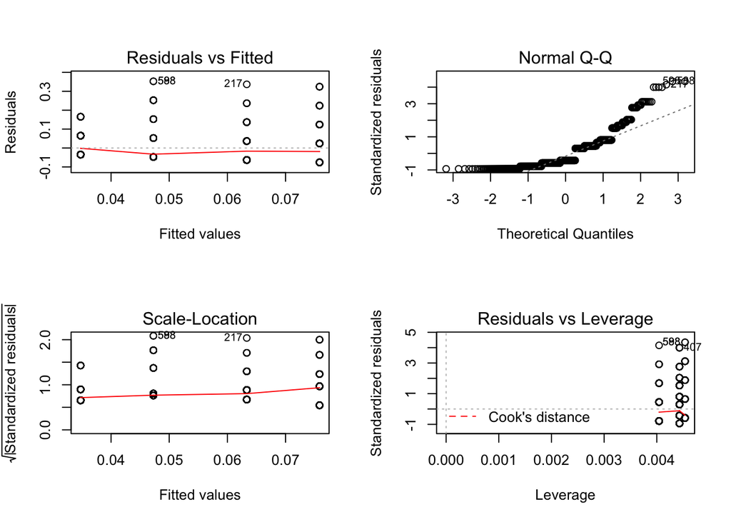

```r
par(mfrow = c(2,2))
plot(ev.pr.lm)
```

```r
par(mfrow = c(1,1))
```

Not a good model.

```r
ev.re.lm <- lm(recall ~ frequent + polysemous, data = data)
summary(ev.re.lm)
```

```
##
## Call:
## lm(formula = recall ~ frequent + polysemous, data = data)
##
## Residuals:
##      Min       1Q   Median       3Q      Max
## -0.07262 -0.06138 -0.03300  0.02256  0.46700
##
## Coefficients:
##                 Estimate Std. Error t value Pr(>|t|)
## (Intercept)     0.072617   0.005919  12.269  < 2e-16 ***
## frequentTRUE   -0.011234   0.006778  -1.657   0.0979 .
## polysemousTRUE -0.028384   0.006778  -4.187 3.19e-05 ***
## ---
## Signif. codes:  0 '***' 0.001 '**' 0.01 '*' 0.05 '.' 0.1 ' ' 1
##
## Residual standard error: 0.08892 on 687 degrees of freedom
## Multiple R-squared:  0.02823,    Adjusted R-squared:  0.0254
## F-statistic: 9.978 on 2 and 687 DF,  p-value: 5.349e-05
```

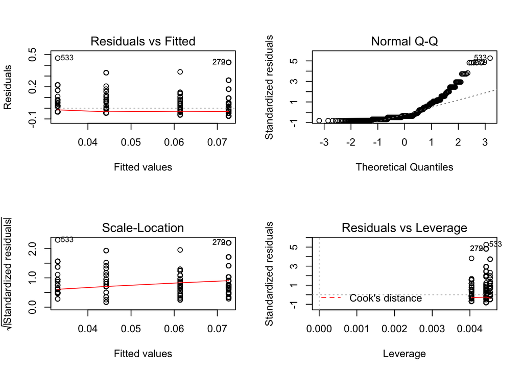

```r
par(mfrow = c(2,2))
plot(ev.re.lm)
```

```r
par(mfrow = c(1,1))
```

Not a good model.

```r
ev.pr.lm2 <- lm(precision ~ frequent + polysemous + lexicon + window + freq_threshold, data = data)
summary(ev.pr.lm2)
```

```
##
## Call:
## lm(formula = precision ~ frequent + polysemous + lexicon + window +
##     freq_threshold, data = data)
##
## Residuals:
##      Min       1Q   Median       3Q      Max
## -0.16197 -0.05045 -0.03461  0.04837  0.35301
##
## Coefficients:
##                  Estimate Std. Error t value Pr(>|t|)
## (Intercept)     6.927e-02  8.919e-03   7.767 2.95e-14 ***
## frequentTRUE   -1.558e-02  5.953e-03  -2.616  0.00909 **
## polysemousTRUE -1.756e-02  6.091e-03  -2.883  0.00406 **
## lexiconPOLLUX   1.102e-01  1.420e-02   7.763 3.03e-14 ***
## lexiconSCHMIDT -6.969e-04  6.267e-03  -0.111  0.91150
## window         -3.849e-04  8.052e-04  -0.478  0.63281
## freq_threshold -8.705e-06  8.439e-05  -0.103  0.91787
## ---
## Signif. codes:  0 '***' 0.001 '**' 0.01 '*' 0.05 '.' 0.1 ' ' 1
##
## Residual standard error: 0.07787 on 683 degrees of freedom
## Multiple R-squared:  0.1193, Adjusted R-squared:  0.1115
## F-statistic: 15.42 on 6 and 683 DF,  p-value: < 2.2e-16
```

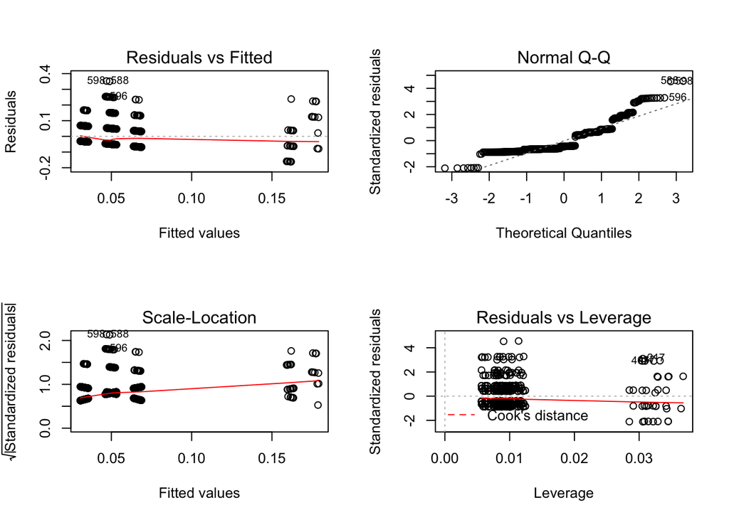

```r
par(mfrow = c(2,2))
plot(ev.pr.lm2)
```

```r
par(mfrow = c(1,1))
```

Not a good model.

Stepwise regression:

```r
ev.pr.m0 <- lm(precision ~ 1, data = data)
ev.pr.lm.step <- step(ev.pr.m0, scope = ~ frequent + polysemous + lexicon + window + recall + freq_threshold)#, direction = "forward")
```

```
## Start:  AIC=-3440.07
## precision ~ 1
##
##                  Df Sum of Sq    RSS     AIC
## + recall          1   2.49475 2.2082 -3959.7
## + lexicon         2   0.46813 4.2348 -3508.4
## + polysemous      1   0.13748 4.5655 -3458.5
## + frequent        1   0.02405 4.6789 -3441.6
## <none>                        4.7030 -3440.1
## + window          1   0.00139 4.7016 -3438.3
## + freq_threshold  1   0.00135 4.7016 -3438.3
##
## Step:  AIC=-3959.71
## precision ~ recall
##
##                  Df Sum of Sq    RSS     AIC
## + lexicon         2   0.41593 1.7923 -4099.7
## + polysemous      1   0.01585 2.1924 -3962.7
## <none>                        2.2082 -3959.7
## + frequent        1   0.00393 2.2043 -3958.9
## + freq_threshold  1   0.00122 2.2070 -3958.1
## + window          1   0.00050 2.2077 -3957.9
## - recall          1   2.49475 4.7030 -3440.1
##
## Step:  AIC=-4099.71
## precision ~ recall + lexicon
##
##                  Df Sum of Sq    RSS     AIC
## + frequent        1   0.01010 1.7822 -4101.6
## <none>                        1.7923 -4099.7
## + window          1   0.00055 1.7917 -4097.9
## + freq_threshold  1   0.00014 1.7921 -4097.8
## + polysemous      1   0.00001 1.7923 -4097.7
## - lexicon         2   0.41593 2.2082 -3959.7
## - recall          1   2.44255 4.2348 -3508.4
##
## Step:  AIC=-4101.61
## precision ~ recall + lexicon + frequent
##
##                  Df Sum of Sq    RSS     AIC
## <none>                        1.7822 -4101.6
## + window          1   0.00053 1.7816 -4099.8
## - frequent        1   0.01010 1.7923 -4099.7
## + freq_threshold  1   0.00006 1.7821 -4099.6
## + polysemous      1   0.00000 1.7822 -4099.6
## - lexicon         2   0.42210 2.2043 -3958.9
## - recall          1   2.41178 4.1940 -3513.1
```

```r
summary(ev.pr.lm.step)
```

```
##
## Call:
## lm(formula = precision ~ recall + lexicon + frequent, data = data)
##
## Residuals:
##       Min        1Q    Median        3Q       Max
## -0.145057 -0.026309 -0.007445  0.004614  0.230953
##
## Coefficients:
##                 Estimate Std. Error t value Pr(>|t|)
## (Intercept)     0.034002   0.003739   9.094  < 2e-16 ***
## recall          0.675224   0.022177  30.447  < 2e-16 ***
## lexiconPOLLUX   0.080277   0.009142   8.781  < 2e-16 ***
## lexiconSCHMIDT -0.026557   0.004122  -6.442 2.21e-10 ***
## frequentTRUE   -0.007693   0.003905  -1.970   0.0492 *
## ---
## Signif. codes:  0 '***' 0.001 '**' 0.01 '*' 0.05 '.' 0.1 ' ' 1
##
## Residual standard error: 0.05101 on 685 degrees of freedom
## Multiple R-squared:  0.6211, Adjusted R-squared:  0.6188
## F-statistic: 280.7 on 4 and 685 DF,  p-value: < 2.2e-16
```

The higher the recall, the higher the precision, as expected. More interestingly, Schmidt’s lexicon is associated to lower precision compared to the baseline, AGWN.

Model diagnostics:

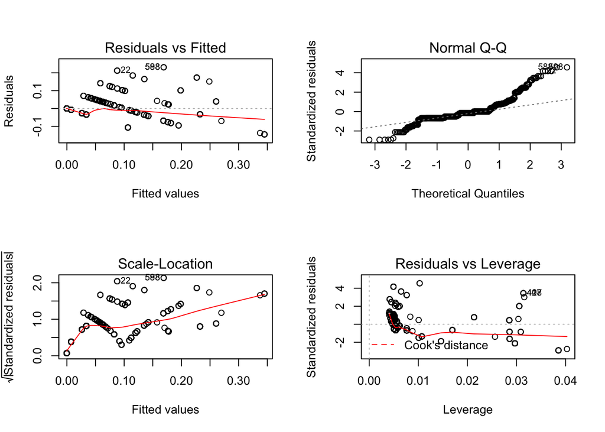

```r
par(mfrow = c(2,2))
plot(ev.pr.lm.step)
```

```r
par(mfrow = c(1,1))
```

Not a great model.

```r
ev.re.m0 <- lm(recall ~ 1, data = data)
ev.re.lm.step <- step(ev.re.m0,
                      scope = ~ frequent + polysemous + lexicon + window + precision)
```

```
## Start:  AIC=-3320.94
## recall ~ 1
##
##              Df Sum of Sq    RSS     AIC
## + precision   1   2.96486 2.6243 -3840.6
## + lexicon     2   0.27679 5.3124 -3352.0
## + polysemous  1   0.13606 5.4531 -3335.9
## + frequent    1   0.01915 5.5700 -3321.3
## <none>                    5.5892 -3320.9
## + window      1   0.00798 5.5812 -3319.9
##
## Step:  AIC=-3840.59
## recall ~ precision
##
##              Df Sum of Sq    RSS     AIC
## + lexicon     2   0.37600 2.2483 -3943.3
## <none>                    2.6243 -3840.6
## + polysemous  1   0.00571 2.6186 -3840.1
## + window      1   0.00357 2.6208 -3839.5
## + frequent    1   0.00023 2.6241 -3838.6
## - precision   1   2.96486 5.5892 -3320.9
##
## Step:  AIC=-3943.29
## recall ~ precision + lexicon
##
##              Df Sum of Sq    RSS     AIC
## + polysemous  1   0.02066 2.2277 -3947.7
## <none>                    2.2483 -3943.3
## + window      1   0.00332 2.2450 -3942.3
## + frequent    1   0.00048 2.2479 -3941.4
## - lexicon     2   0.37600 2.6243 -3840.6
## - precision   1   3.06407 5.3124 -3352.0
##
## Step:  AIC=-3947.66
## recall ~ precision + lexicon + polysemous
##
##              Df Sum of Sq    RSS     AIC
## <none>                    2.2277 -3947.7
## + window      1   0.00336 2.2243 -3946.7
## + frequent    1   0.00036 2.2273 -3945.8
## - polysemous  1   0.02066 2.2483 -3943.3
## - lexicon     2   0.39095 2.6186 -3840.1
## - precision   1   2.97423 5.2019 -3364.5
```

```r
                      #direction = "forward"
summary(ev.re.lm.step)
```

```
##
## Call:
## lm(formula = recall ~ precision + lexicon + polysemous, data = data)
##
## Residuals:
##      Min       1Q   Median       3Q      Max
## -0.15445 -0.03198 -0.01482  0.01828  0.31073
##
## Coefficients:
##                 Estimate Std. Error t value Pr(>|t|)
## (Intercept)    -0.006976   0.004405  -1.584   0.1137
## precision       0.843005   0.027876  30.242  < 2e-16 ***
## lexiconPOLLUX  -0.048343   0.010777  -4.486 8.52e-06 ***
## lexiconSCHMIDT  0.038958   0.004509   8.641  < 2e-16 ***
## polysemousTRUE -0.011308   0.004486  -2.521   0.0119 *
## ---
## Signif. codes:  0 '***' 0.001 '**' 0.01 '*' 0.05 '.' 0.1 ' ' 1
##
## Residual standard error: 0.05703 on 685 degrees of freedom
## Multiple R-squared:  0.6014, Adjusted R-squared:  0.5991
## F-statistic: 258.4 on 4 and 685 DF,  p-value: < 2.2e-16
```

```r
png(paste(path, "Evaluation", "plots", "model_diagnostics.png", sep = "/"))
par(mfrow = c(2,2))
plot(ev.re.lm.step)
par(mfrow = c(1,1))
dev.off()
```

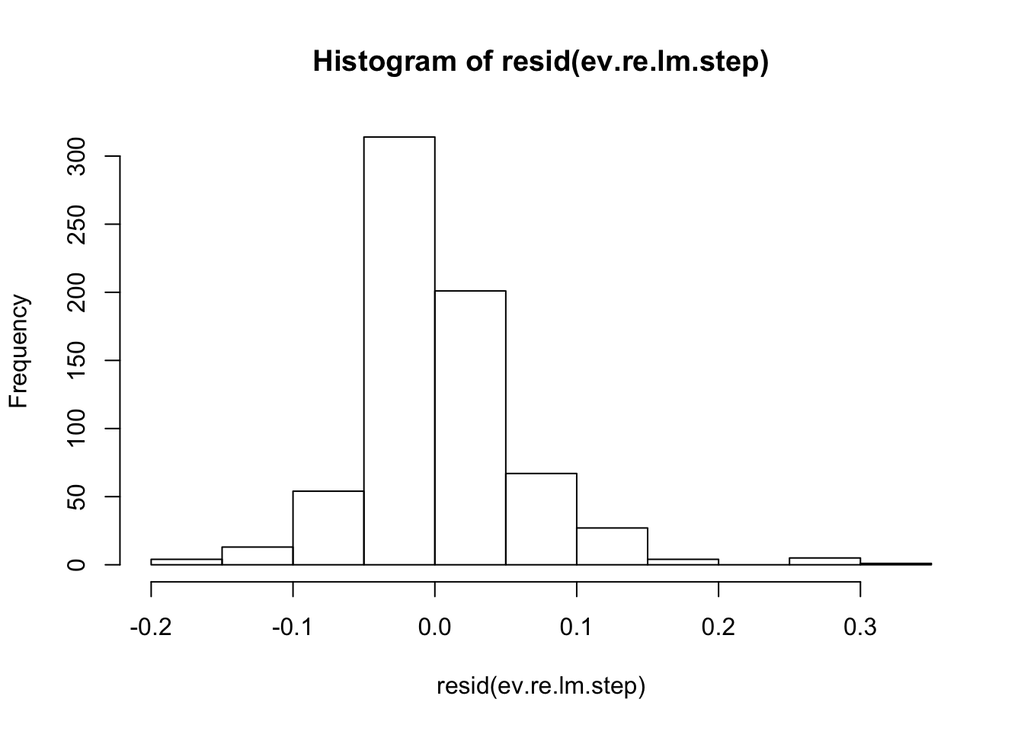

```r
hist(resid(ev.re.lm.step))
```

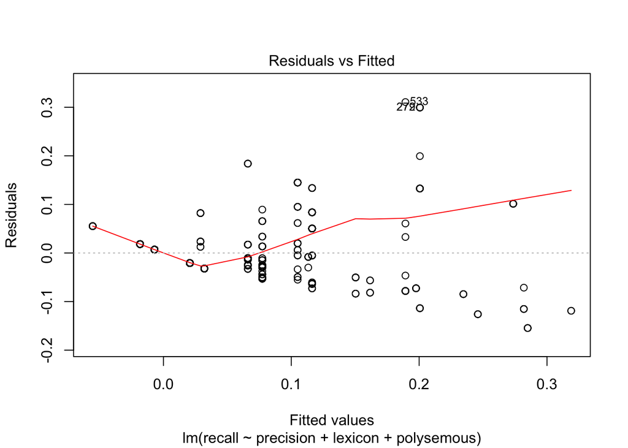

```r
plot(ev.re.lm.step, which = 1)
```

The higher the precision, the higher the recall, as expected. More interestingly, Schmidt’s lexicon is associated to higher recall compared to the baseline, AGWN.

Check https://data.library.virginia.edu/diagnostic-plots/.